# U.S. Weather Events Impact Analysis

DanGuti

February 7, 2016

**Synopsis**  
The analysis is started by retrieving weather event data and slimming down the data to only necessary variables.

# Data Processing

First step for the analysis is to download the data and assign it to a usable environment variable.

```r
u <- "https://d396qusza40orc.cloudfront.net/repdata%2Fdata%2FStormData.csv.bz2" #file url address
download.file(u,"StormData.csv.bz2") #download zip file
sData <- read.csv("StormData.csv.bz2") #read csv data

str(sData) #get some idea what variables are available.
```

```
## 'data.frame':    902297 obs. of  37 variables:
##  $ STATE__   : num  1 1 1 1 1 1 1 1 1 1 ...
##  $ BGN_DATE  : Factor w/ 16335 levels "10/10/1954 0:00:00",..: 6523 6523 4213 11116 1426 1426 1462 2873 3980 3980 ...
##  $ BGN_TIME  : Factor w/ 3608 levels "000","0000","00:00:00 AM",..: 212 257 2645 1563 2524 3126 122 1563 3126 3126 ...
##  $ TIME_ZONE : Factor w/ 22 levels "ADT","AKS","AST",..: 7 7 7 7 7 7 7 7 7 7 ...
##  $ COUNTY    : num  97 3 57 89 43 77 9 123 125 57 ...
##  $ COUNTYNAME: Factor w/ 29601 levels "","5NM E OF MACKINAC BRIDGE TO PRESQUE ISLE LT MI",..: 13513 1873 4598 10592 4372 10094 1973 23873 24418 4598 ...
##  $ STATE     : Factor w/ 72 levels "AK","AL","AM",..: 2 2 2 2 2 2 2 2 2 2 ...
##  $ EVTYPE    : Factor w/ 985 levels "?","ABNORMALLY DRY",..: 830 830 830 830 830 830 830 830 830 830 ...
##  $ BGN_RANGE : num  0 0 0 0 0 0 0 0 0 0 ...
##  $ BGN_AZI   : Factor w/ 35 levels "","E","Eas","EE",..: 1 1 1 1 1 1 1 1 1 1 ...
##  $ BGN_LOCATI: Factor w/ 54429 levels "","?","(01R)AFB GNRY RNG AL",..: 1 1 1 1 1 1 1 1 1 1 ...
##  $ END_DATE  : Factor w/ 6663 levels "","10/10/1993 0:00:00",..: 1 1 1 1 1 1 1 1 1 1 ...
##  $ END_TIME  : Factor w/ 3647 levels "","?","0000",..: 1 1 1 1 1 1 1 1 1 1 ...
##  $ COUNTY_END: num  0 0 0 0 0 0 0 0 0 0 ...
```

[output cut: 23 more lines]

```r
require(plyr)
```

```r
require(ggplot2)
require(reshape2)
```

## Data Reduction

Now we want to make things easier for our machines by getting rid of the variables that are not of interest to us.

```r
intvars <- c("EVTYPE","FATALITIES","INJURIES","PROPDMG", "PROPDMGEXP",
             "CROPDMG", "CROPDMGEXP") #index of variables of interest
sData <- sData[intvars] #reduce data to only relevant variables
str(sData) #to show our reduced variables
```

```
## 'data.frame':    902297 obs. of  7 variables:
##  $ EVTYPE    : Factor w/ 985 levels "?","ABNORMALLY DRY",..: 830 830 830 830 830 830 830 830 830 830 ...
##  $ FATALITIES: num  0 0 0 0 0 0 0 0 1 0 ...
##  $ INJURIES  : num  15 0 2 2 2 6 1 0 14 0 ...
##  $ PROPDMG   : num  25 2.5 25 2.5 2.5 2.5 2.5 2.5 25 25 ...
##  $ PROPDMGEXP: Factor w/ 19 levels "","-","?","+",..: 17 17 17 17 17 17 17 17 17 17 ...
##  $ CROPDMG   : num  0 0 0 0 0 0 0 0 0 0 ...
##  $ CROPDMGEXP: Factor w/ 9 levels "","?","0","2",..: 1 1 1 1 1 1 1 1 1 1 ...
```

## Data Cleaning

```r
require(plyr)
```

```r
require(ggplot2)
require(reshape2)
cData <- data.frame("EVTYPE" = sData$EVTYPE, "FATALITIES" = sData$FATALITIES,
                    "INJURIES" = sData$INJURIES)## Initialize cData frame where clean exponential values will be entered

## Making the damage exponentials uniform numerical data
### Replace levels for property damage exponential
levels(sData$PROPDMG) #look at the levels we have from property damage exponentials
```

[output not shown]

```r
replacing <- c("?" = NA,
              "-" = 0, "+" = 0,
              "h" = 2, "H" = 2,
              "K" = 3,
              "m" = 6, "M" = 6,
              "B" = 9) #list of value equivalencies to transform letters to number exponential
cleanPDMGEXP <- revalue(sData$PROPDMGEXP, replacing) #transform letters to exponential values. The given number is assumed to be of the form 10^x.

lv <- levels(cleanPDMGEXP) #save levels of property damage exponential
lv[1] = NA #when no damage is reported, list as NA
levels(cleanPDMGEXP) = lv #Fix levels on cleanPDMGEXP
cleanPDMGEXP = as.numeric(levels(cleanPDMGEXP)[cleanPDMGEXP]) #converts factor variable to numeric
cData$totPdmg <- sData$PROPDMG * 10^cleanPDMGEXP
```

So far, we cleaned the property damage exponential variable of non-valid values, then changed all values to numeric; and finally, created a total property damage variable that gives a dollar amount for property damage.  
Our next step is to do the same for the corresponding crop damage variables.

```r
### Replace levels for crop damage exponential
levels(sData$CROPDMGEXP) #look at the levels we have from property damage exponentials
```

```
## [1] ""  "?" "0" "2" "B" "k" "K" "m" "M"
```

```r
replacing <- c("?" = NA,
               "k" = 3, "K" = 3,
               "m" = 6, "M" = 6,
               "B" = 9) #list of value equivalencies to transform letters to number exponential
cleanCDMGEXP <- revalue(sData$CROPDMGEXP, replacing) #transform letters to exponential values. The given number is assumed to be of the form 10^x.

lv <- levels(cleanCDMGEXP) #save levels of property damage exponential
lv[1] = NA #when no damage is reported, list as NA
levels(cleanCDMGEXP) = lv #Fix levels on cleanPDMGEXP
cleanCDMGEXP = as.numeric(levels(cleanCDMGEXP)[cleanCDMGEXP])#converts factor variable to numeric, the -1 offsets the value to match the levels
cData$totCdmg <- sData$CROPDMG * 10^cleanCDMGEXP

### Finally, we change NA's to 0 in the totCdmg and totPdmg variables, so that we only have dollar amounts and can come up with one single damage No.
cData$totPdmg[is.na(cData$totPdmg)] <- 0 #change NA's to 0
cData$totCdmg[is.na(cData$totCdmg)] <- 0 #change NA's to 0
cData$totDmg <- cData$totPdmg + cData$totCdmg #create totals column for damage
```

Now we have clean and useful variables gathered in cData. Let’s take a look:

```r
head(cData)
```

```
##    EVTYPE FATALITIES INJURIES totPdmg totCdmg totDmg
## 1 TORNADO          0       15   25000       0  25000
## 2 TORNADO          0        0    2500       0   2500
## 3 TORNADO          0        2   25000       0  25000
## 4 TORNADO          0        2    2500       0   2500
## 5 TORNADO          0        2    2500       0   2500
## 6 TORNADO          0        6    2500       0   2500
```

This looks much better now. Let’s see what we can find out about weather events.

# Data Summary

Now we can produce a useful summary of the data that we are interested in. We aggregate data by event type, so that we know how many fatalities and injuries each specific type of event causes.

```r
## Harmful events - Injuries or Fatalities
Harm <- aggregate(cData[,2:3], list(EVTYPE = cData$EVTYPE), sum) #create table with fatality and Injury aggregates


## Damage
Dam <- aggregate(cData[,4:6], list(EVTYPE = cData$EVTYPE), sum) #aggregate fatalities
```

With all the data available to us, let’s take a look at the results.

# Results

Now let’s order the events my most harmful, and most damaging. Let’s consider most harmful to be those with most fatalities, and similarly most damaging to be those with most *total* damages in $ amount.

```r
TopHarm <- head(arrange(Harm,desc(Harm$FATALITIES))) #retrieve 6 EVTYPEs with most fatalities
TopDam <- head(arrange(Dam,desc(Dam$totDmg))) #retrieve 6 EVTYPEs with most total damage
TopHarm
```

```
##           EVTYPE FATALITIES INJURIES
## 1        TORNADO       5633    91346
## 2 EXCESSIVE HEAT       1903     6525
## 3    FLASH FLOOD        978     1777
## 4           HEAT        937     2100
## 5      LIGHTNING        816     5230
## 6      TSTM WIND        504     6957
```

```r
TopDam
```

```
##              EVTYPE      totPdmg    totCdmg       totDmg
## 1             FLOOD 144657709800 5661968450 150319678250
## 2 HURRICANE/TYPHOON  69305840000 2607872800  71913712800
## 3           TORNADO  56947380674  414953270  57362333944
## 4       STORM SURGE  43323536000       5000  43323541000
## 5              HAIL  15735267456 3025954470  18761221926
## 6       FLASH FLOOD  16822673772 1421317100  18243990872
```

Now we can observe the most damaging and harmful events as shown in the tables above. Finally, let’s plot that data for a more visual representation of the data.

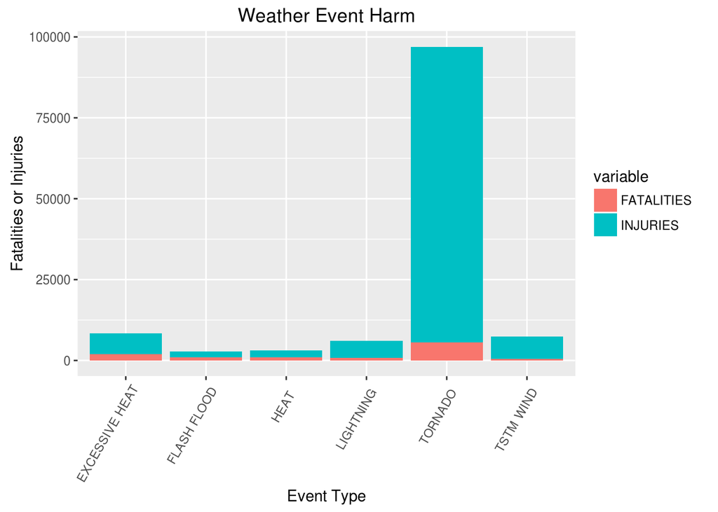

```r
TH <- melt(TopHarm, id = "EVTYPE")


ggplot(data=TH, aes(x=EVTYPE, y=value, fill=variable)) +
  geom_bar(stat="identity") +
  theme(axis.text.x=element_text(angle=60,hjust=0.9,vjust=0.9))+
  ggtitle("Weather Event Harm") +
  labs(x="Event Type",y="Fatalities or Injuries")
```

Figure 1. Number of fatalities/injuries by event type.

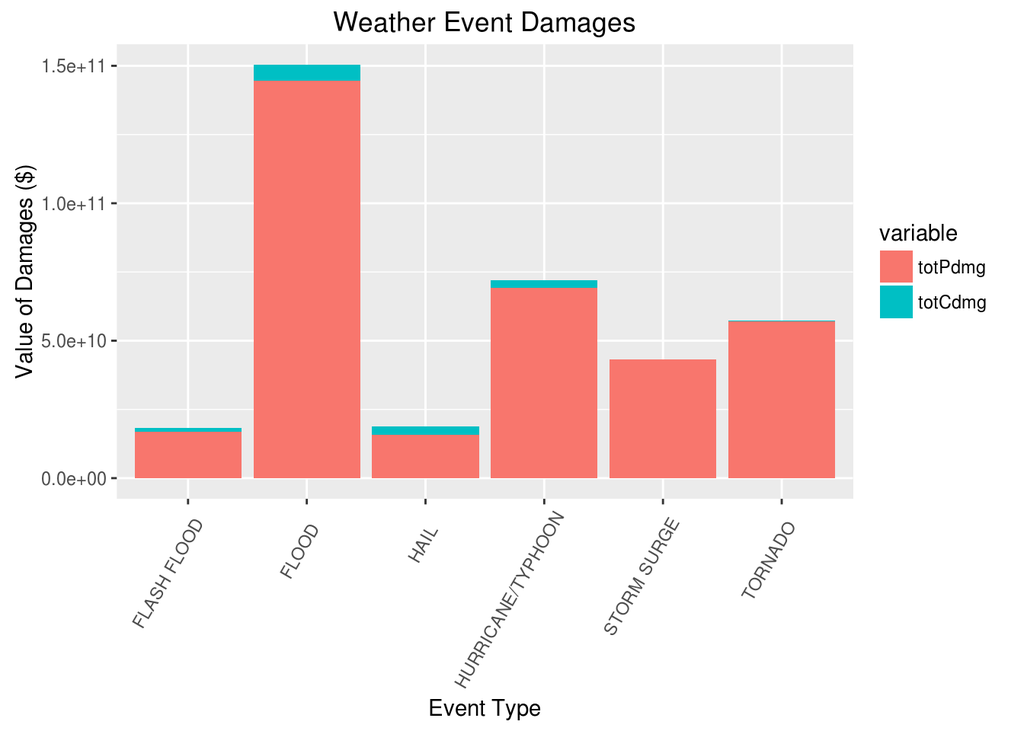

```r
TD <- melt(TopDam[,1:3], id = "EVTYPE")
ggplot(data=TD, aes(x=EVTYPE, y=value, fill=variable)) +
  geom_bar(stat="identity") +
  theme(axis.text.x=element_text(angle=60,hjust=0.9,vjust=0.9))+
  ggtitle("Weather Event Damages") +
  labs(x="Event Type",y="Value of Damages ($)")
```

Figure 2. Damage in USD per event type.

From these plots it is easier to conclude a few things:

1. The most harmful event is no doubt tornadoes, with the most fatalities and injuries.
2. The most damaging event on the other hand are floods, with almost double the amount of total damages as the second place.
3. Within the events that cause the most damage, property damage is by far the most significant contribution to the damages total.
4. Tornadoes with the most casualties by far, and a third place in damages is quite possibly the most relevant type of event.